# Limits to the Policy Relevance of Past Climate Research

Reproducible Data Analysis

Author

Nicolas Gauthier

Published

Last updated: October 21, 2026

## Introduction

This is a fully reproducible analysis written in R and Quarto. The source code for this document, including all the R code to preprocess the data, run the analysis, and produce the tables you see below, is available [here on GitHub](https://github.com/nick-gauthier/learning-from-climates-past/blob/main/analysis.qmd).

This analysis pulls data directly from the original Excel Spreadsheet [at this link](https://github.com/nick-gauthier/learning-from-climates-past/blob/main/Limits%20Database%20Final.xlsx), so the tables will update automatically when the analysis is rerun if the spreadsheet changes.

## Packages Used

We used R v. 4.4.2 (R Core Team 2024) and the following R packages: gtsummary v. 2.5.0 (Sjoberg et al. 2021), labelled v. 2.16.0 (Larmarange 2025), tidyverse v. 2.0.0 (Wickham et al. 2019).

## Simple Questions

### 1. How many publications do we have from each discipline?

| **Variable** | **N = 1,188**<sup>1</sup> |
| --- | --- |
| Discipline |  |
| Archaeology | 147 (12%) |
| Economics | 5 (0.4%) |
| Epidemiology | 2 (0.2%) |
| Geography | 25 (2.1%) |
| History | 206 (17%) |
| Joint Fields | 210 (18%) |
| Literature | 35 (2.9%) |
| Other | 13 (1.1%) |
| Paleoclimatology | 545 (46%) |

<sup>1</sup> n (%)

### 2. How many publications are from each region?

| **Variable** | **N = 1,188**<sup>1</sup> |
| --- | --- |
| Geographic Region |  |
| Africa | 44 (3.7%) |
| Americas | 171 (14%) |
| Asia | 271 (23%) |
| Europe | 346 (29%) |
| Global | 231 (19%) |
| Middle East | 60 (5.1%) |
| Oceania | 25 (2.1%) |
| Polar | 40 (3.4%) |

<sup>1</sup> n (%)

### 3. How many publications are from each period?

Note that N is larger here because each paper can cover multiple time periods.

| **Variable** | **N = 3,258**<sup>1</sup> |
| --- | --- |
| Period |  |
| Pleistocene | 65 (2.0%) |
| Early-Mid Holocene | 144 (4.4%) |
| Ancient | 343 (11%) |
| Medieval | 567 (17%) |
| Early Modern | 719 (22%) |
| Modern | 754 (23%) |
| Present | 666 (20%) |

<sup>1</sup> n (%)

| **Variable** | **N = 1,188**<sup>1</sup> |
| --- | --- |
| Method |  |
| Both | 164 (14%) |
| Neither | 126 (11%) |
| Qualitative | 219 (18%) |
| Quantitative | 679 (57%) |

<sup>1</sup> n (%)

### 5. How many of our publications are original research, a literature review, or a response article?

| **Variable** | **N = 1,188**<sup>1</sup> |
| --- | --- |
| type |  |
| Lit. Review/Method Intervention | 165 (14%) |
| Original Research | 1,021 (86%) |
| Response Article | 2 (0.2%) |

<sup>1</sup> n (%)

### 6. How many publications are books, “book/theses” (PhD theses), articles, or “chapter/articles” (book chapters)?

| **Variable** | **N = 1,188**<sup>1</sup> |
| --- | --- |
| Publication Type |  |
| Article | 884 (74%) |
| Book | 55 (4.6%) |
| Book/Thesis | 2 (0.2%) |
| Chapter/Article | 247 (21%) |

<sup>1</sup> n (%)

### 7. How many of our publications use AGW to argue for their importance?

| **Variable** | **N = 1,188**<sup>1</sup> |
| --- | --- |
| Uses AGW | 658 (55%) |

<sup>1</sup> n (%)

### 8. How many of our publications include lessons for the present/future?

| **Variable** | **N = 1,188**<sup>1</sup> |
| --- | --- |
| Includes lessons | 194 (16%) |

<sup>1</sup> n (%)

### 9. What types of lessons or recommendations are most common?

Note, some papers can have multiple recommendation types. This analysis counts those separately (like we do for periods) so our N is greater than the number of articles.

| **Variable** | **N = 1,221**<sup>1</sup> |
| --- | --- |
| rec_type |  |
| Broad, abstract, or vague | 94 (7.7%) |
| Specific but not actionable | 77 (6.3%) |
| Specific and actionable | 56 (4.6%) |
| No recommendation | 994 (81%) |

<sup>1</sup> n (%)

### 10. Among lessons (so leaving out “none of the above”) what types of lessons or recommendations are most common?

| **Variable** | **N = 227**<sup>1</sup> |
| --- | --- |
| rec_type |  |
| Broad, abstract, or vague | 94 (41%) |
| Specific but not actionable | 77 (34%) |
| Specific and actionable | 56 (25%) |
| No recommendation | 0 (0%) |

<sup>1</sup> n (%)

### 11. How many of our publications in each discipline use methods that are quantitative, qualitative, both, or neither?

| **Variable** | **Both** N = 164<sup>1</sup> | **Neither** N = 126<sup>1</sup> | **Qualitative** N = 219<sup>1</sup> | **Quantitative** N = 679<sup>1</sup> | **p-value**<sup>2</sup> |
| --- | --- | --- | --- | --- | --- |
| Discipline |  |  |  |  | <0.001 |
| Archaeology | 29 (18%) | 16 (13%) | 25 (11%) | 77 (11%) |  |
| Economics | 2 (1.2%) | 0 (0%) | 1 (0.5%) | 2 (0.3%) |  |
| Epidemiology | 0 (0%) | 1 (0.8%) | 0 (0%) | 1 (0.1%) |  |
| Geography | 3 (1.8%) | 0 (0%) | 11 (5.0%) | 11 (1.6%) |  |
| History | 30 (18%) | 36 (29%) | 127 (58%) | 13 (1.9%) |  |
| Joint Fields | 91 (55%) | 23 (18%) | 8 (3.7%) | 88 (13%) |  |
| Literature | 0 (0%) | 4 (3.2%) | 31 (14%) | 0 (0%) |  |
| Other | 1 (0.6%) | 4 (3.2%) | 5 (2.3%) | 3 (0.4%) |  |
| Paleoclimatology | 8 (4.9%) | 42 (33%) | 11 (5.0%) | 484 (71%) |  |

<sup>1</sup> n (%)  
<sup>2</sup> Fisher’s Exact Test for Count Data with simulated p-value (based on 2000 replicates)

### 12. How many publications that are *not* in Paleoclimatology/Historical Climatology use Quantitative Analysis?

351 publications from disciplines other than paleoclimatology use quantitative analysis.

### 13. What percentage of publications in every method consider each region?

| **Variable** | **Both** N = 164<sup>1</sup> | **Neither** N = 126<sup>1</sup> | **Qualitative** N = 219<sup>1</sup> | **Quantitative** N = 679<sup>1</sup> | **p-value**<sup>2</sup> |
| --- | --- | --- | --- | --- | --- |
| Geographic Region |  |  |  |  | <0.001 |
| Africa | 9 (5.5%) | 0 (0%) | 9 (4.1%) | 26 (3.8%) |  |
| Americas | 18 (11%) | 6 (4.8%) | 38 (17%) | 109 (16%) |  |
| Asia | 25 (15%) | 9 (7.1%) | 9 (4.1%) | 228 (34%) |  |
| Europe | 66 (40%) | 26 (21%) | 96 (44%) | 158 (23%) |  |
| Global | 22 (13%) | 82 (65%) | 43 (20%) | 84 (12%) |  |
| Middle East | 20 (12%) | 0 (0%) | 12 (5.5%) | 28 (4.1%) |  |
| Oceania | 3 (1.8%) | 1 (0.8%) | 6 (2.7%) | 15 (2.2%) |  |
| Polar | 1 (0.6%) | 2 (1.6%) | 6 (2.7%) | 31 (4.6%) |  |

<sup>1</sup> n (%)  
<sup>2</sup> Fisher’s Exact Test for Count Data with simulated p-value (based on 2000 replicates)

## Compound Questions

For tables that expand publications across multiple periods or lesson types, observations overlap and the independence assumption of these tests is not met; p-values may be too small or too large and should be interpreted cautiously.

### 1. What percentage of publications in each discipline and method use AGW to argue for their importance?

| **Variable** | **No** N = 530<sup>1</sup> | **Yes** N = 658<sup>1</sup> | **p-value**<sup>2</sup> |
| --- | --- | --- | --- |
| Discipline |  |  | <0.001 |
| Archaeology | 72 (14%) | 75 (11%) |  |
| Economics | 2 (0.4%) | 3 (0.5%) |  |
| Epidemiology | 0 (0%) | 2 (0.3%) |  |
| Geography | 8 (1.5%) | 17 (2.6%) |  |
| History | 130 (25%) | 76 (12%) |  |
| Joint Fields | 120 (23%) | 90 (14%) |  |
| Literature | 15 (2.8%) | 20 (3.0%) |  |
| Other | 3 (0.6%) | 10 (1.5%) |  |
| Paleoclimatology | 180 (34%) | 365 (55%) |  |
| Method |  |  | <0.001 |
| Both | 95 (18%) | 69 (10%) |  |
| Neither | 54 (10%) | 72 (11%) |  |
| Qualitative | 122 (23%) | 97 (15%) |  |
| Quantitative | 259 (49%) | 420 (64%) |  |

<sup>1</sup> n (%)  
<sup>2</sup> Fisher’s Exact Test for Count Data with simulated p-value (based on 2000 replicates); Pearson’s Chi-squared test

### 2a. What percentage of publications in Paleoclimatology/Historical Climatology use modern global warming to argue for their significance? What percentage of publications in all *other* disciplines do the same?

| **Variable** | **All other disciplines** N = 643<sup>1</sup> | **Paleoclimatology** N = 545<sup>1</sup> | **p-value**<sup>2</sup> |
| --- | --- | --- | --- |
| Uses AGW | 293 (46%) | 365 (67%) | <0.001 |

<sup>1</sup> n (%)  
<sup>2</sup> Pearson’s Chi-squared test

### 2b. What percentage of publications using quantitative analysis use modern global warming to argue for their significance? And what percentage of publications using the other methods do the same?

Note that here we again combine Quantitative and Both categories.

| **Variable** | **Other Methods** N = 345<sup>1</sup> | **Quantitative** N = 843<sup>1</sup> | **p-value**<sup>2</sup> |
| --- | --- | --- | --- |
| Uses AGW | 169 (49%) | 489 (58%) | 0.005 |

<sup>1</sup> n (%)  
<sup>2</sup> Pearson’s Chi-squared test

### 3a. What percentage of publications from each region use AGW to argue for their importance?

| **Variable** | **No** N = 530<sup>1</sup> | **Yes** N = 658<sup>1</sup> | **p-value**<sup>2</sup> |
| --- | --- | --- | --- |
| Geographic Region |  |  | <0.001 |
| Africa | 21 (4.0%) | 23 (3.5%) |  |
| Americas | 71 (13%) | 100 (15%) |  |
| Asia | 89 (17%) | 182 (28%) |  |
| Europe | 210 (40%) | 136 (21%) |  |
| Global | 87 (16%) | 144 (22%) |  |
| Middle East | 37 (7.0%) | 23 (3.5%) |  |
| Oceania | 9 (1.7%) | 16 (2.4%) |  |
| Polar | 6 (1.1%) | 34 (5.2%) |  |

<sup>1</sup> n (%)  
<sup>2</sup> Pearson’s Chi-squared test

### 3b. What percentage of publications from each period use AGW to argue for their importance?

| **Variable** | **No** N = 1,230<sup>1</sup> | **Yes** N = 2,028<sup>1</sup> | **p-value**<sup>2</sup> |
| --- | --- | --- | --- |
| period |  |  | <0.001 |
| Pleistocene | 27 (2.2%) | 38 (1.9%) |  |
| Early-Mid Holocene | 70 (5.7%) | 74 (3.6%) |  |
| Ancient | 162 (13%) | 181 (8.9%) |  |
| Medieval | 245 (20%) | 322 (16%) |  |
| Early Modern | 274 (22%) | 445 (22%) |  |
| Modern | 255 (21%) | 499 (25%) |  |
| Present | 197 (16%) | 469 (23%) |  |

<sup>1</sup> n (%)  
<sup>2</sup> Pearson’s Chi-squared test

### 4. What percentage of publications that cover each region use global warming to argue for their significance?

| **Variable** | **Africa** N = 44<sup>1</sup> | **Americas** N = 171<sup>1</sup> | **Asia** N = 271<sup>1</sup> | **Europe** N = 346<sup>1</sup> | **Global** N = 231<sup>1</sup> | **Middle East** N = 60<sup>1</sup> | **Oceania** N = 25<sup>1</sup> | **Polar** N = 40<sup>1</sup> | **p-value**<sup>2</sup> |
| --- | --- | --- | --- | --- | --- | --- | --- | --- | --- |
| Uses AGW | 23 (52%) | 100 (58%) | 182 (67%) | 136 (39%) | 144 (62%) | 23 (38%) | 16 (64%) | 34 (85%) | <0.001 |

<sup>1</sup> n (%)  
<sup>2</sup> Pearson’s Chi-squared test

### 5. What percentage of publications that include lessons come from each discipline? What percentage comes from each method?

| **Variable** | **No** N = 994<sup>1</sup> | **Yes** N = 194<sup>1</sup> | **p-value**<sup>2</sup> |
| --- | --- | --- | --- |
| Discipline |  |  | <0.001 |
| Archaeology | 108 (11%) | 39 (20%) |  |
| Economics | 3 (0.3%) | 2 (1.0%) |  |
| Epidemiology | 1 (0.1%) | 1 (0.5%) |  |
| Geography | 19 (1.9%) | 6 (3.1%) |  |
| History | 160 (16%) | 46 (24%) |  |
| Joint Fields | 174 (18%) | 36 (19%) |  |
| Literature | 24 (2.4%) | 11 (5.7%) |  |
| Other | 5 (0.5%) | 8 (4.1%) |  |
| Paleoclimatology | 500 (50%) | 45 (23%) |  |
| Method |  |  | <0.001 |
| Both | 130 (13%) | 34 (18%) |  |
| Neither | 101 (10%) | 25 (13%) |  |
| Qualitative | 156 (16%) | 63 (32%) |  |
| Quantitative | 607 (61%) | 72 (37%) |  |

<sup>1</sup> n (%)  
<sup>2</sup> Fisher’s Exact Test for Count Data with simulated p-value (based on 2000 replicates); Pearson’s Chi-squared test

### 6a. What percentage of publications in each discipline include lessons for the present/future?

| **Variable** | **Archaeology** N = 147<sup>1</sup> | **Economics** N = 5<sup>1</sup> | **Epidemiology** N = 2<sup>1</sup> | **Geography** N = 25<sup>1</sup> | **History** N = 206<sup>1</sup> | **Joint Fields** N = 210<sup>1</sup> | **Literature** N = 35<sup>1</sup> | **Other** N = 13<sup>1</sup> | **Paleoclimatology** N = 545<sup>1</sup> | **p-value**<sup>2</sup> |
| --- | --- | --- | --- | --- | --- | --- | --- | --- | --- | --- |
| Includes lessons | 39 (27%) | 2 (40%) | 1 (50%) | 6 (24%) | 46 (22%) | 36 (17%) | 11 (31%) | 8 (62%) | 45 (8.3%) | <0.001 |

<sup>1</sup> n (%)  
<sup>2</sup> Fisher’s Exact Test for Count Data with simulated p-value (based on 2000 replicates)

### 6b. What percentage of publications in each method include lessons for the present/future?

| **Variable** | **Both** N = 164<sup>1</sup> | **Neither** N = 126<sup>1</sup> | **Qualitative** N = 219<sup>1</sup> | **Quantitative** N = 679<sup>1</sup> | **p-value**<sup>2</sup> |
| --- | --- | --- | --- | --- | --- |
| Includes lessons | 34 (21%) | 25 (20%) | 63 (29%) | 72 (11%) | <0.001 |

<sup>1</sup> n (%)  
<sup>2</sup> Pearson’s Chi-squared test

### 7. What percentage of publications that include lessons focus on each region and period?

| **Variable** | **No** N = 994<sup>1</sup> | **Yes** N = 194<sup>1</sup> | **p-value**<sup>2</sup> |
| --- | --- | --- | --- |
| Geographic Region |  |  | <0.001 |
| Africa | 34 (3.4%) | 10 (5.2%) |  |
| Americas | 137 (14%) | 34 (18%) |  |
| Asia | 247 (25%) | 24 (12%) |  |
| Europe | 303 (30%) | 43 (22%) |  |
| Global | 174 (18%) | 57 (29%) |  |
| Middle East | 48 (4.8%) | 12 (6.2%) |  |
| Oceania | 18 (1.8%) | 7 (3.6%) |  |
| Polar | 33 (3.3%) | 7 (3.6%) |  |

<sup>1</sup> n (%)  
<sup>2</sup> Fisher’s Exact Test for Count Data with simulated p-value (based on 2000 replicates)

| **Variable** | **No** N = 2,697<sup>1</sup> | **Yes** N = 561<sup>1</sup> | **p-value**<sup>2</sup> |
| --- | --- | --- | --- |
| period |  |  | 0.071 |
| Pleistocene | 46 (1.7%) | 19 (3.4%) |  |
| Early-Mid Holocene | 114 (4.2%) | 30 (5.3%) |  |
| Ancient | 290 (11%) | 53 (9.4%) |  |
| Medieval | 482 (18%) | 85 (15%) |  |
| Early Modern | 600 (22%) | 119 (21%) |  |
| Modern | 622 (23%) | 132 (24%) |  |
| Present | 543 (20%) | 123 (22%) |  |

<sup>1</sup> n (%)  
<sup>2</sup> Pearson’s Chi-squared test

### 8a. What percentage of publications from each region include lessons for the present/future?

| **Variable** | **Africa** N = 44<sup>1</sup> | **Americas** N = 171<sup>1</sup> | **Asia** N = 271<sup>1</sup> | **Europe** N = 346<sup>1</sup> | **Global** N = 231<sup>1</sup> | **Middle East** N = 60<sup>1</sup> | **Oceania** N = 25<sup>1</sup> | **Polar** N = 40<sup>1</sup> | **p-value**<sup>2</sup> |
| --- | --- | --- | --- | --- | --- | --- | --- | --- | --- |
| Includes lessons | 10 (23%) | 34 (20%) | 24 (8.9%) | 43 (12%) | 57 (25%) | 12 (20%) | 7 (28%) | 7 (18%) | <0.001 |

<sup>1</sup> n (%)  
<sup>2</sup> Fisher’s Exact Test for Count Data with simulated p-value (based on 2000 replicates)

### 8b. What percentage of publications from each period include lessons for the present/future?

| **Variable** | **Pleistocene** N = 65<sup>1</sup> | **Early-Mid Holocene** N = 144<sup>1</sup> | **Ancient** N = 343<sup>1</sup> | **Medieval** N = 567<sup>1</sup> | **Early Modern** N = 719<sup>1</sup> | **Modern** N = 754<sup>1</sup> | **Present** N = 666<sup>1</sup> | **p-value**<sup>2</sup> |
| --- | --- | --- | --- | --- | --- | --- | --- | --- |
| Includes lessons | 19 (29%) | 30 (21%) | 53 (15%) | 85 (15%) | 119 (17%) | 132 (18%) | 123 (18%) | 0.071 |

<sup>1</sup> n (%)  
<sup>2</sup> Pearson’s Chi-squared test

### 9a. What percentage of publications in each discipline include distinct types of recommendation?

| **Variable** | **Archaeology** N = 156<sup>1</sup> | **Economics** N = 5<sup>1</sup> | **Epidemiology** N = 2<sup>1</sup> | **Geography** N = 27<sup>1</sup> | **History** N = 213<sup>1</sup> | **Joint Fields** N = 216<sup>1</sup> | **Literature** N = 35<sup>1</sup> | **Other** N = 16<sup>1</sup> | **Paleoclimatology** N = 551<sup>1</sup> | **p-value**<sup>2</sup> |
| --- | --- | --- | --- | --- | --- | --- | --- | --- | --- | --- |
| rec_type |  |  |  |  |  |  |  |  |  | <0.001 |
| Broad, abstract, or vague | 15 (9.6%) | 1 (20%) | 0 (0%) | 5 (19%) | 27 (13%) | 21 (9.7%) | 8 (23%) | 4 (25%) | 13 (2.4%) |  |
| Specific but not actionable | 20 (13%) | 0 (0%) | 1 (50%) | 2 (7.4%) | 19 (8.9%) | 12 (5.6%) | 1 (2.9%) | 3 (19%) | 19 (3.4%) |  |
| Specific and actionable | 13 (8.3%) | 1 (20%) | 0 (0%) | 1 (3.7%) | 7 (3.3%) | 9 (4.2%) | 2 (5.7%) | 4 (25%) | 19 (3.4%) |  |
| No recommendation | 108 (69%) | 3 (60%) | 1 (50%) | 19 (70%) | 160 (75%) | 174 (81%) | 24 (69%) | 5 (31%) | 500 (91%) |  |

<sup>1</sup> n (%)  
<sup>2</sup> Fisher’s Exact Test for Count Data with simulated p-value (based on 2000 replicates)

### 9b. What percentage of publications in each method include distinct types of recommendation?

| **Variable** | **Both** N = 175<sup>1</sup> | **Neither** N = 131<sup>1</sup> | **Qualitative** N = 233<sup>1</sup> | **Quantitative** N = 682<sup>1</sup> | **p-value**<sup>2</sup> |
| --- | --- | --- | --- | --- | --- |
| rec_type |  |  |  |  | <0.001 |
| Broad, abstract, or vague | 23 (13%) | 11 (8.4%) | 39 (17%) | 21 (3.1%) |  |
| Specific but not actionable | 12 (6.9%) | 11 (8.4%) | 25 (11%) | 29 (4.3%) |  |
| Specific and actionable | 10 (5.7%) | 8 (6.1%) | 13 (5.6%) | 25 (3.7%) |  |
| No recommendation | 130 (74%) | 101 (77%) | 156 (67%) | 607 (89%) |  |

<sup>1</sup> n (%)  
<sup>2</sup> Pearson’s Chi-squared test

### 10a. What percentage of publications from each region include distinct types of recommendation?

| **Variable** | **Africa** N = 44<sup>1</sup> | **Americas** N = 175<sup>1</sup> | **Asia** N = 273<sup>1</sup> | **Europe** N = 350<sup>1</sup> | **Global** N = 246<sup>1</sup> | **Middle East** N = 64<sup>1</sup> | **Oceania** N = 28<sup>1</sup> | **Polar** N = 41<sup>1</sup> | **p-value**<sup>2</sup> |
| --- | --- | --- | --- | --- | --- | --- | --- | --- | --- |
| rec_type |  |  |  |  |  |  |  |  | <0.001 |
| Broad, abstract, or vague | 2 (4.5%) | 17 (9.7%) | 7 (2.6%) | 27 (7.7%) | 28 (11%) | 5 (7.8%) | 4 (14%) | 4 (9.8%) |  |
| Specific but not actionable | 3 (6.8%) | 6 (3.4%) | 9 (3.3%) | 14 (4.0%) | 28 (11%) | 10 (16%) | 3 (11%) | 4 (9.8%) |  |
| Specific and actionable | 5 (11%) | 15 (8.6%) | 10 (3.7%) | 6 (1.7%) | 16 (6.5%) | 1 (1.6%) | 3 (11%) | 0 (0%) |  |
| No recommendation | 34 (77%) | 137 (78%) | 247 (90%) | 303 (87%) | 174 (71%) | 48 (75%) | 18 (64%) | 33 (80%) |  |

<sup>1</sup> n (%)  
<sup>2</sup> Fisher’s Exact Test for Count Data with simulated p-value (based on 2000 replicates)

### 10b. What percentage of publications from each period include distinct types of recommendation?

Note, because each paper can have multiple periods *and* recommendation types, there are different ways to do this. Here we just look at all combinations, which is not necessarily the best way to do this!

| **Variable** | **Pleistocene** N = 77<sup>1</sup> | **Early-Mid Holocene** N = 157<sup>1</sup> | **Ancient** N = 358<sup>1</sup> | **Medieval** N = 585<sup>1</sup> | **Early Modern** N = 742<sup>1</sup> | **Modern** N = 778<sup>1</sup> | **Present** N = 687<sup>1</sup> | **p-value**<sup>2</sup> |
| --- | --- | --- | --- | --- | --- | --- | --- | --- |
| rec_type |  |  |  |  |  |  |  | 0.022 |
| Broad, abstract, or vague | 11 (14%) | 12 (7.6%) | 23 (6.4%) | 42 (7.2%) | 54 (7.3%) | 59 (7.6%) | 47 (6.8%) |  |
| Specific but not actionable | 12 (16%) | 20 (13%) | 29 (8.1%) | 34 (5.8%) | 50 (6.7%) | 55 (7.1%) | 53 (7.7%) |  |
| Specific and actionable | 8 (10%) | 11 (7.0%) | 16 (4.5%) | 27 (4.6%) | 38 (5.1%) | 42 (5.4%) | 44 (6.4%) |  |
| No recommendation | 46 (60%) | 114 (73%) | 290 (81%) | 482 (82%) | 600 (81%) | 622 (80%) | 543 (79%) |  |

<sup>1</sup> n (%)  
<sup>2</sup> Fisher’s Exact Test for Count Data with simulated p-value (based on 2000 replicates)

### 11. What percentage of publications that use AGW to argue for their importance include lessons for the present/future?

| **Variable** | **No** N = 530<sup>1</sup> | **Yes** N = 658<sup>1</sup> | **p-value**<sup>2</sup> |
| --- | --- | --- | --- |
| Includes lessons | 31 (5.8%) | 163 (25%) | <0.001 |

<sup>1</sup> n (%)  
<sup>2</sup> Pearson’s Chi-squared test

What percentage of paleosciences/history/literature, etc. articles that use AGW to argue for their importance include lessons for the present/future?

| **Variable** | **Archaeology** N = 75<sup>1</sup> | **Economics** N = 3<sup>1</sup> | **Epidemiology** N = 2<sup>1</sup> | **Geography** N = 17<sup>1</sup> | **History** N = 76<sup>1</sup> | **Joint Fields** N = 90<sup>1</sup> | **Literature** N = 20<sup>1</sup> | **Other** N = 10<sup>1</sup> | **Paleoclimatology** N = 365<sup>1</sup> | **p-value**<sup>2</sup> |
| --- | --- | --- | --- | --- | --- | --- | --- | --- | --- | --- |
| Includes lessons | 36 (48%) | 1 (33%) | 1 (50%) | 5 (29%) | 36 (47%) | 28 (31%) | 9 (45%) | 7 (70%) | 40 (11%) | <0.001 |

<sup>1</sup> n (%)  
<sup>2</sup> Fisher’s Exact Test for Count Data with simulated p-value (based on 2000 replicates)

Same as above, but now broken down by region:

| **Variable** | **Africa** N = 23<sup>1</sup> | **Americas** N = 100<sup>1</sup> | **Asia** N = 182<sup>1</sup> | **Europe** N = 136<sup>1</sup> | **Global** N = 144<sup>1</sup> | **Middle East** N = 23<sup>1</sup> | **Oceania** N = 16<sup>1</sup> | **Polar** N = 34<sup>1</sup> | **p-value**<sup>2</sup> |
| --- | --- | --- | --- | --- | --- | --- | --- | --- | --- |
| Includes lessons | 9 (39%) | 30 (30%) | 21 (12%) | 31 (23%) | 47 (33%) | 11 (48%) | 7 (44%) | 7 (21%) | <0.001 |

<sup>1</sup> n (%)  
<sup>2</sup> Fisher’s Exact Test for Count Data with simulated p-value (based on 2000 replicates)

Broken down by period:

| **Variable** | **Pleistocene** N = 38<sup>1</sup> | **Early-Mid Holocene** N = 74<sup>1</sup> | **Ancient** N = 181<sup>1</sup> | **Medieval** N = 322<sup>1</sup> | **Early Modern** N = 445<sup>1</sup> | **Modern** N = 499<sup>1</sup> | **Present** N = 469<sup>1</sup> | **p-value**<sup>2</sup> |
| --- | --- | --- | --- | --- | --- | --- | --- | --- |
| Includes lessons | 17 (45%) | 26 (35%) | 44 (24%) | 74 (23%) | 100 (22%) | 113 (23%) | 105 (22%) | 0.014 |

<sup>1</sup> n (%)  
<sup>2</sup> Pearson’s Chi-squared test

Broken down by method:

| **Variable** | **Both** N = 69<sup>1</sup> | **Neither** N = 72<sup>1</sup> | **Qualitative** N = 97<sup>1</sup> | **Quantitative** N = 420<sup>1</sup> | **p-value**<sup>2</sup> |
| --- | --- | --- | --- | --- | --- |
| Includes lessons | 27 (39%) | 23 (32%) | 48 (49%) | 65 (15%) | <0.001 |

<sup>1</sup> n (%)  
<sup>2</sup> Pearson’s Chi-squared test

Broken down by publication type:

| **Variable** | **Lit. Review/Method Intervention** N = 97<sup>1</sup> | **Original Research** N = 561<sup>1</sup> | **p-value**<sup>2</sup> |
| --- | --- | --- | --- |
| Includes lessons | 36 (37%) | 127 (23%) | 0.002 |

<sup>1</sup> n (%)  
<sup>2</sup> Pearson’s Chi-squared test

Broken down by publication format:

| **Variable** | **Article** N = 533<sup>1</sup> | **Book** N = 39<sup>1</sup> | **Book/Thesis** N = 2<sup>1</sup> | **Chapter/Article** N = 84<sup>1</sup> | **p-value**<sup>2</sup> |
| --- | --- | --- | --- | --- | --- |
| Includes lessons | 114 (21%) | 20 (51%) | 2 (100%) | 27 (32%) | <0.001 |

<sup>1</sup> n (%)  
<sup>2</sup> Fisher’s exact test

### 12. Are there journals which are particularly correlated with including lessons for the present/future?

Of the journals with 10 or more entries in our database, the following journals have the highest proportion of papers with recommendations for the present or future. However, only Climate and American Literature has a significantly higher proportion of recommendations than the average for all papers, after correcting for multiple comparisons.

```
# A tibble: 29 × 7
   journal                  n_papers n_recs prop_recs    pval  p_adj significant
   <chr>                       <int>  <int>     <dbl>   <dbl>  <dbl> <lgl>
 1 Climate and American Li…       19      9     0.474 0.00158 0.0458 TRUE
 2 Proceedings of the Nati…       38     12     0.316 0.0246  0.178  FALSE
 3 Global and Planetary Ch…       20      6     0.3   0.122   0.395  FALSE
 4 Nature                         10      3     0.3   0.215   0.402  FALSE
 5 Nature Communications          10      3     0.3   0.215   0.402  FALSE
 6 Environmental Research …       11      3     0.273 0.403   0.557  FALSE
 7 Geophysical Research Le…       24      6     0.25  0.265   0.405  FALSE
 8 Climate Changes in the …       14      3     0.214 0.489   0.636  FALSE
 9 Climate Change and Huma…       10      2     0.2   0.672   0.696  FALSE
10 Climatic Change                25      5     0.2   0.589   0.657  FALSE
# ℹ 19 more rows
```

### 13. What percentage of each publication type provides lessons versus AGW justifications?

| **Variable** | **Article** N = 884<sup>1</sup> | **Book** N = 55<sup>1</sup> | **Book/Thesis** N = 2<sup>1</sup> | **Chapter/Article** N = 247<sup>1</sup> | **p-value**<sup>2</sup> |
| --- | --- | --- | --- | --- | --- |
| Includes lessons | 130 (15%) | 26 (47%) | 2 (100%) | 36 (15%) | <0.001 |
| Uses AGW | 533 (60%) | 39 (71%) | 2 (100%) | 84 (34%) | <0.001 |

<sup>1</sup> n (%)  
<sup>2</sup> Fisher’s Exact Test for Count Data with simulated p-value (based on 2000 replicates)

| **Variable** | **Article (combined)** N = 1,131<sup>1</sup> | **Book** N = 55<sup>1</sup> | **Book/Thesis** N = 2<sup>1</sup> | **p-value**<sup>2</sup> |
| --- | --- | --- | --- | --- |
| Includes lessons | 166 (15%) | 26 (47%) | 2 (100%) | <0.001 |
| Uses AGW | 617 (55%) | 39 (71%) | 2 (100%) | 0.014 |

<sup>1</sup> n (%)  
<sup>2</sup> Fisher’s Exact Test for Count Data with simulated p-value (based on 2000 replicates)

## Publication year

| date | publications | provides_lessons | percent_providing_lessons |
| --- | --- | --- | --- |
| 2017 | 263 | 42 | 16.0 |
| 2018 | 273 | 47 | 17.2 |
| 2019 | 239 | 28 | 11.7 |
| 2020 | 180 | 31 | 17.2 |
| 2021 | 233 | 46 | 19.7 |

## Figures

### Figure 1

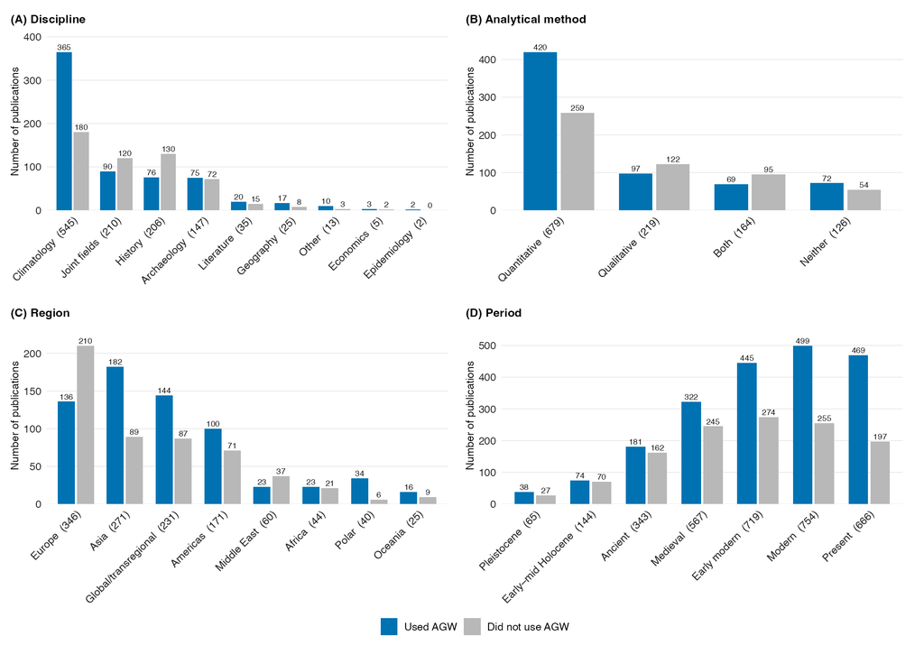

### Figure 2

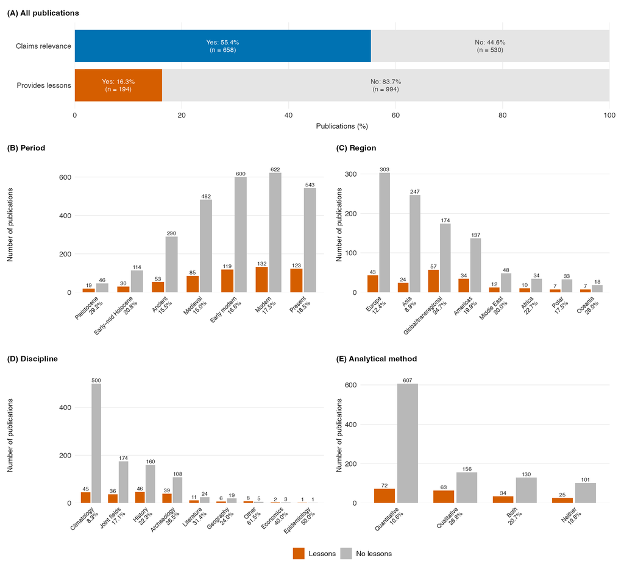

### Figure 3

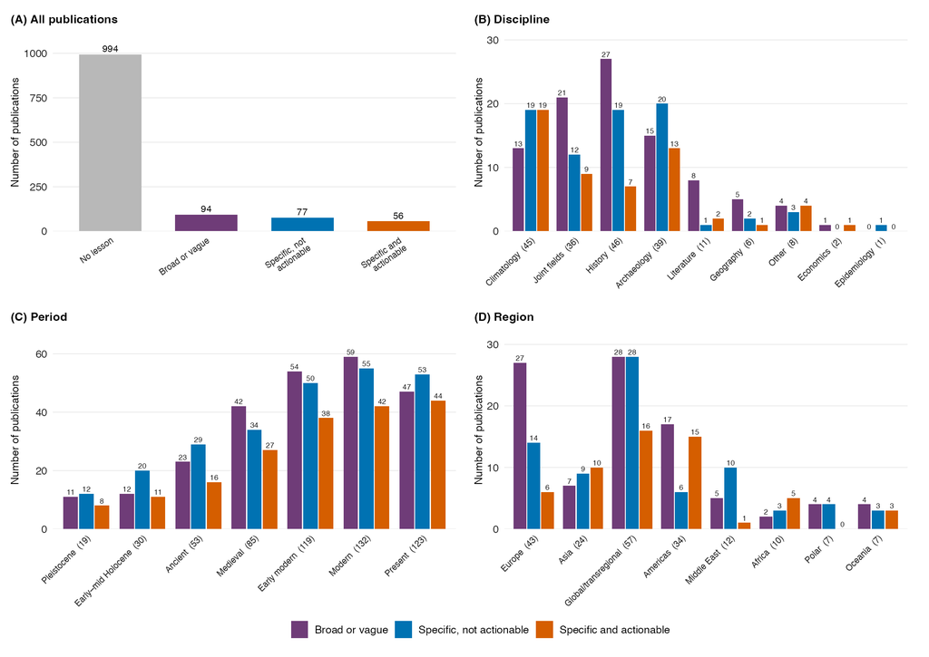

### Figure S2-bars

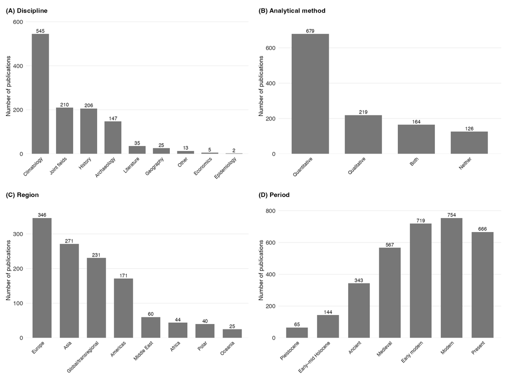

### Figure S2-treemaps

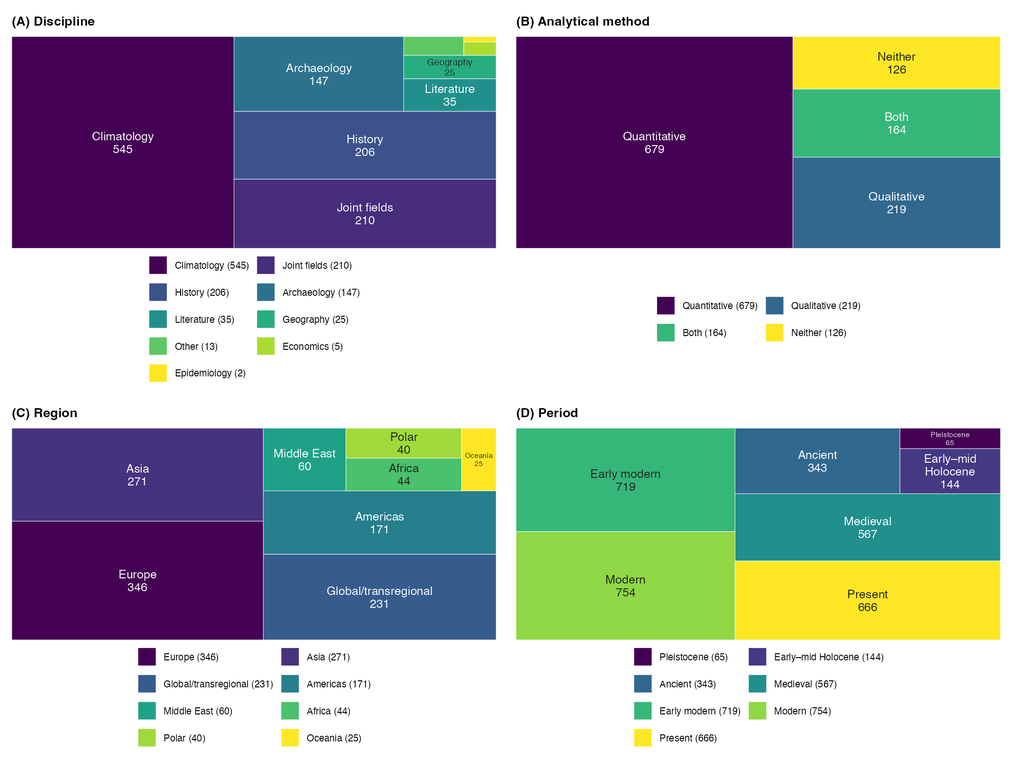

## References

Larmarange, Joseph. 2025. *labelled: Manipulating Labelled Data*. https://CRAN.R-project.org/package=labelled.

R Core Team. 2024. *R: A Language and Environment for Statistical Computing*. Vienna, Austria: R Foundation for Statistical Computing. https://www.R-project.org/.

Sjoberg, Daniel D., Karissa Whiting, Michael Curry, Jessica A. Lavery, and Joseph Larmarange. 2021. “Reproducible Summary Tables with the Gtsummary Package.” *The R Journal* 13: 570–80. https://doi.org/10.32614/RJ-2021-053.

Wickham, Hadley, Mara Averick, Jennifer Bryan, Winston Chang, Lucy D’Agostino McGowan, Romain François, Garrett Grolemund, et al. 2019. “Welcome to the tidyverse.” *Journal of Open Source Software* 4 (43): 1686. https://doi.org/10.21105/joss.01686.